# 08 Dollars Under the Curve

The other day, I was reflecting on modeling practices in fundraising. The most common application I’ve seen – and the one this entire series covers – is prioritizing prospects based on their expected giving.

It’s not immediately obvious how to go about comparing different techniques given that the usual accuracy metrics like classification error, RMSE, probability calibration, etc. are not directly comparable, not to mention hard classifiers and various machine learning-inspired methods. However, since the difference in output between these different modeling techniques, heuristics, and algorithms ultimately comes down to sort order, why not compare that sort order directly?

# Setup

```r
library(tidyverse)
library(reshape2)
library(gridExtra)
library(splines)
library(lubridate)
library(wranglR)
library(Boruta)
library(foreach)
library(doParallel)
library(glmnet)
library(glmnetUtils)
library(mgcv)
# Functions adapted from previous analysis steps
source('code/functions.R')
# Visualization functions adapted fron previous analysis steps
source('code/functions_viz.R')
# Set number of available CPU cores
registerDoParallel(detectCores() - 2)
```

```r
# Parameters
train_fy <- 2016
filepath <- 'data/2018-11-30 point-in-time data.xlsx'
sheetname <- 'Select point_in_time_model'
# Import data
source('code/generate-pit-data.R')
# Run data generation functions
modeling.data <- generate_pit_data(filepath, sheetname) %>%
  generate_additional_predictors()
```

```
 27249 failed to parse.
```

# Models

## Linear regression fit to all data

lm_all: Fit a linear regression model predicting dollars given to the entire dataset (including nondonors).

```r
lm_all <- lm(
  rv.amt ~
  COMMITTEE_KSM_LDR +
  ns(CRU_PFY1, df = 1) +
  ns(CRU_PFY2, df = 1) +
  ns(CRU_PFY3, df = 1) +
  ns(CRU_PFY4, df = 1) +
  ns(CRU_PFY5, df = 1) +
  ns(EVALUATION_LOWER_BOUND, df = 1) +
  GIFT_CLUB_NU_LDR_YRS +
  ns(GIFTS_ALLOCS_SUPPORTED, df = 1) +
  ns(GIFTS_OUTRIGHTS_PAYMENTS, df = 1) +
  ns(GIVING_CRU_TOTAL, df = 1) +
  ns(GIVING_MAX_CASH_YR, df = 1) +
  ns(GIVING_MAX_PLEDGE_AMT, df = 1) +
  ns(GIVING_MAX_PLEDGE_FY, df = 1) +
  HOUSEHOLD_CONTINENT +
  KSM_GOS_FLAG +
  LOYAL_5_PCT_ANY +
  ns(NGC_PFY1, df = 1) +
  ns(NGC_PFY2, df = 1) +
  ns(NGC_PFY3, df = 1) +
  ns(NGC_PFY4, df = 1) +
  ns(NGC_PFY5, df = 1) +
  PREF_ADDR_TYPE_CODE +
  PROGRAM_GROUP +
  ns(RECORD_YR, df = 5) +
  ns(UOR_LOWER_BOUND, df = 1) +
  UPGRADE3_CASH +
  ns(VELOCITY3_LIN_NGC, df = 5) +
  ns(VISITS_5FY, df = 1)
  , data = modeling.data
)
```

## GAM fit to all data

gam_all: Fit a generalized additive model predicting dollars given to the entire dataset (including nondonors).

```r
gam_all <- gam(
  rv.amt ~ COMMITTEE_KSM_LDR + s(CRU_PFY1) + s(CRU_PFY2) +
    s(CRU_PFY3) + s(CRU_PFY4) + s(CRU_PFY5) + s(EVALUATION_LOWER_BOUND) +
    GIFT_CLUB_NU_LDR_YRS + s(GIFTS_ALLOCS_SUPPORTED) + s(GIFTS_OUTRIGHTS_PAYMENTS) +
    s(GIVING_CRU_TOTAL) + s(GIVING_MAX_CASH_YR) + s(GIVING_MAX_PLEDGE_AMT) +
    s(GIVING_MAX_PLEDGE_FY) + HOUSEHOLD_CONTINENT + KSM_GOS_FLAG + LOYAL_5_PCT_ANY + s(NGC_PFY1) +
    s(NGC_PFY2) + s(NGC_PFY3) + s(NGC_PFY4) + s(NGC_PFY5) + PREF_ADDR_TYPE_CODE +
    PROGRAM_GROUP + s(RECORD_YR) + s(UOR_LOWER_BOUND) + UPGRADE3_CASH + s(VELOCITY3_LIN_NGC) +
    s(VISITS_5FY)
  , data = modeling.data
  , family = 'gaussian'
  , control = list(nthreads = 3)
)
```

## LM fit to donors

lm_donors: Fit a linear regression model predicting dollars given by donors only.

```r
lm_donors <- lm(
  rv.amt ~
  COMMITTEE_KSM_LDR +
  ns(CRU_PFY1, df = 2) +
  ns(CRU_PFY2, df = 1) +
  ns(CRU_PFY3, df = 1) +
  ns(CRU_PFY4, df = 1) +
  ns(CRU_PFY5, df = 1) +
  ns(EVALUATION_LOWER_BOUND, df = 1) +
  GIFT_CLUB_NU_LDR_YRS +
  ns(GIFTS_ALLOCS_SUPPORTED, df = 1) +
  ns(GIFTS_OUTRIGHTS_PAYMENTS, df = 1) +
  ns(GIVING_CRU_TOTAL, df = 1) +
  ns(GIVING_MAX_CASH_YR, df = 1) +
  ns(GIVING_MAX_PLEDGE_AMT, df = 1) +
  ns(GIVING_MAX_PLEDGE_FY, df = 1) +
  HOUSEHOLD_CONTINENT +
  KSM_GOS_FLAG +
  LOYAL_5_PCT_ANY +
  ns(NGC_PFY1, df = 2) +
  ns(NGC_PFY2, df = 1) +
  ns(NGC_PFY3, df = 1) +
  ns(NGC_PFY4, df = 1) +
  ns(NGC_PFY5, df = 1) +
  PREF_ADDR_TYPE_CODE +
  PROGRAM_GROUP +
  ns(RECORD_YR, df = 5) +
  ns(UOR_LOWER_BOUND, df = 1) +
  UPGRADE3_CASH +
  ns(VELOCITY3_LIN_NGC, df = 7) +
  ns(VISITS_5FY, df = 1)
  , data = modeling.data %>% filter(rv.gave == TRUE)
)
```

## GAM fit to donors

gam_donors: Fit a generalized additive model predicting dollars given by donors only.

```r
gam_donors <- gam(
  rv.amt ~
  COMMITTEE_KSM_LDR +
  s(CRU_PFY1) +
  s(CRU_PFY2) +
  s(CRU_PFY3) +
  s(CRU_PFY4) +
  s(CRU_PFY5) +
  s(EVALUATION_LOWER_BOUND) +
  GIFT_CLUB_NU_LDR_YRS +
  s(GIFTS_ALLOCS_SUPPORTED) +
  s(GIFTS_OUTRIGHTS_PAYMENTS) +
  s(GIVING_CRU_TOTAL) +
  s(GIVING_MAX_CASH_YR) +
  s(GIVING_MAX_PLEDGE_AMT) +
  s(GIVING_MAX_PLEDGE_FY) +
  HOUSEHOLD_CONTINENT +
  KSM_GOS_FLAG +
  LOYAL_5_PCT_ANY +
  s(NGC_PFY1) +
  s(NGC_PFY2) +
  s(NGC_PFY3) +
  s(NGC_PFY4) +
  s(NGC_PFY5) +
  PREF_ADDR_TYPE_CODE +
  PROGRAM_GROUP +
  s(RECORD_YR) +
  s(UOR_LOWER_BOUND) +
  UPGRADE3_CASH +
  s(VELOCITY3_LIN_NGC) +
  s(VISITS_5FY)
  , data = modeling.data %>% filter(rv.gave)
  , family = 'gaussian'
  , control = list(nthreads = 10)
)
```

## GLM probability model

glm_p: Fit a binary logistic regression model to classify individuals as donors or nondonors.

```r
glm_p <- glm(
  rv.gave ~
  PROGRAM_GROUP +
  PREF_ADDR_TYPE_CODE +
  HOUSEHOLD_CONTINENT +
  BUS_IS_EMPLOYED +
  HAS_HOME_ADDR +
  HAS_HOME_PHONE +
  ns(YEARS_SINCE_FIRST_GIFT, df = 1) +
  ns(GIVING_FIRST_YEAR_CASH_AMT, df = 1) +
  ns(GIVING_MAX_PLEDGE_AMT, df = 1) +
  ns(GIVING_CASH_TOTAL, df = 1) +
  ns(GIVING_PLEDGE_TOTAL, df = 1) +
  ns(GIVING_CRU_TOTAL, df = 1) +
  ns(GIFTS_ALLOCS_SUPPORTED, df = 1) +
  ns(GIFTS_FYS_SUPPORTED, df = 1) +
  ns(GIFTS_CASH, df = 1) +
  ns(GIFTS_PLEDGES, df = 1) +
  ns(CASH_PFY1, df = 1) +
  ns(CASH_PFY2, df = 1) +
  ns(CASH_PFY3, df = 1) +
  ns(CASH_PFY4, df = 1) +
  ns(CASH_PFY5, df = 1) +
  CRU_GIVING_SEGMENT +
  ns(EVALUATION_LOWER_BOUND, df = 1) +
  ns(UOR_LOWER_BOUND, df = 1) +
  ns(MONTHS_ASSIGNED, df = 1) +
  ns(COMMITTEE_NU_DISTINCT, df = 1) +
  ns(COMMITTEE_NU_YEARS, df = 1) +
  ns(COMMITTEE_KSM_DISTINCT, df = 1) +
  ns(EVENTS_PREV_3_FY, df = 1) +
  ns(EVENTS_CFY, df = 1) +
  ns(EVENTS_PFY1, df = 1) +
  ns(ATHLETICS_TICKET_YEARS, df = 1) +
  ns(YEARS_SINCE_ATHLETICS_TICKETS, df = 1) +
  ns(RECORD_YR, df = 5) +
  ns(YEARS_SINCE_MAX_CASH_YR, df = 3) +
  GIVING_MAX_CASH_MO +
  KSM_PROSPECT +
  ns(VISITORS_5FY, df = 1) +
  LOYAL_5_PCT_CASH +
  UPGRADE3_CASH +
  VELOCITY3_LIN_CASH +
  SPOUSE_ALUM
  , data = modeling.data
  , family = 'binomial'
)
```

## GAM probability model

gam_p: Fit a generalized additive model to classify individuals as donors or nondonors.

```r
gam_p <- gam(
  rv.gave ~
  PROGRAM_GROUP +
  PREF_ADDR_TYPE_CODE +
  HOUSEHOLD_CONTINENT +
  BUS_IS_EMPLOYED +
  HAS_HOME_ADDR +
  HAS_HOME_PHONE +
  s(YEARS_SINCE_FIRST_GIFT) +
  s(GIVING_FIRST_YEAR_CASH_AMT) +
  s(GIVING_MAX_PLEDGE_AMT) +
  s(GIVING_CASH_TOTAL) +
  s(GIVING_PLEDGE_TOTAL) +
  s(GIVING_CRU_TOTAL) +
  s(GIFTS_ALLOCS_SUPPORTED) +
  s(GIFTS_FYS_SUPPORTED) +
  s(GIFTS_CASH) +
  s(GIFTS_PLEDGES, k = 4) +
  s(CASH_PFY1) +
  s(CASH_PFY2) +
  s(CASH_PFY3) +
  s(CASH_PFY4) +
  s(CASH_PFY5) +
  CRU_GIVING_SEGMENT +
  s(EVALUATION_LOWER_BOUND) +
  s(UOR_LOWER_BOUND) +
  s(MONTHS_ASSIGNED) +
  s(COMMITTEE_NU_DISTINCT) +
  s(COMMITTEE_NU_YEARS) +
  s(COMMITTEE_KSM_DISTINCT) +
  s(EVENTS_PREV_3_FY) +
  s(EVENTS_CFY) +
  s(EVENTS_PFY1) +
  s(ATHLETICS_TICKET_YEARS) +
  s(YEARS_SINCE_ATHLETICS_TICKETS) +
  s(RECORD_YR) +
  s(YEARS_SINCE_MAX_CASH_YR) +
  GIVING_MAX_CASH_MO +
  KSM_PROSPECT +
  s(VISITORS_5FY) +
  LOYAL_5_PCT_CASH +
  UPGRADE3_CASH +
  VELOCITY3_LIN_CASH +
  SPOUSE_ALUM
  , data = modeling.data
  , family = 'binomial'
  , control = list(nthreads = 10)
)
```

## Managed, evaluation, and past giving

eval_giving: order entities by having a KSM manager, then by university overall rating, then by evaluation rating, then by total past giving (NGC), then by last year’s giving (NGC), and finally by alpha ordering.

```r
eval_giving <- modeling.data %>%
  arrange(
    desc(KSM_GOS_FLAG)
    , desc(UOR_LOWER_BOUND)
    , desc(EVALUATION_LOWER_BOUND)
    , desc(GIVING_NGC_TOTAL)
    , desc(NGC_PFY1)
    , REPORT_NAME
  ) %>% select(
    ID_NUMBER
    , KSM_GOS_FLAG
    , UOR_LOWER_BOUND
    , EVALUATION_LOWER_BOUND
    , GIVING_NGC_TOTAL
    , NGC_PFY1
    , REPORT_NAME
    , rv.amt
  ) %>% mutate(
    fitted = nrow(modeling.data) - row_number()
    , giving = log10plus1(rv.amt, inverse = TRUE)
  )
```

# Dollars under the curve

```r
# DUC data generation function
duc_data_gen <- function(fitted, actual) {
  data.frame(
    fitted = fitted %>% unlist()
    , logdollars = actual %>% unlist()
    , dollars = log10plus1(actual, inverse = TRUE) %>% unlist()
  ) %>% arrange(desc(fitted)) %>%
    mutate(
      logdollars = cumsum(logdollars) / sum(logdollars)
      , dollars = cumsum(dollars) / sum(dollars)
      , pct = (row_number() %>% as.numeric()) / length(actual)
     ) %>%
    return()
}
```

```r
# Create predictions
predictions <- data.frame(
  truth = modeling.data$rv.amt
  , lm_all = lm_all$fitted
  , gam_all = gam_all$fitted
  , lm_donors = predict(lm_donors, newdata = modeling.data)
  , gam_donors = predict(gam_donors, newdata = modeling.data)
  , glm_p = glm_p$fitted
  , gam_p = gam_p$fitted
) %>% mutate(
  ev_glm_lm = glm_p * lm_donors
  , ev_gam_lm = gam_p * lm_donors
  , ev_gam_gam = gam_p * gam_donors
)
```

```r
# Create lines for plotting
duc_data <- rbind(
  data.frame(model = 'lm all', duc_data_gen(predictions$lm_all, predictions$truth))
  , data.frame(model = 'gam all', duc_data_gen(predictions$gam_all, predictions$truth))
  , data.frame(model = 'lm donors', duc_data_gen(predictions$lm_donors, predictions$truth))
  , data.frame(model = 'gam donors', duc_data_gen(predictions$gam_donors, predictions$truth))
  , data.frame(model = 'glm p', duc_data_gen(predictions$glm_p, predictions$truth))
  , data.frame(model = 'gam p', duc_data_gen(predictions$gam_p, predictions$truth))
  , data.frame(model = 'lm donors', duc_data_gen(predictions$lm_donors, predictions$truth))
  , data.frame(model = 'gam donors', duc_data_gen(predictions$gam_donors, predictions$truth))
  , data.frame(model = 'EV glm lm', duc_data_gen(predictions$ev_glm_lm, predictions$truth))
  , data.frame(model = 'EV gam lm', duc_data_gen(predictions$ev_gam_lm, predictions$truth))
  , data.frame(model = 'EV gam gam', duc_data_gen(predictions$ev_gam_gam, predictions$truth))
  , data.frame(model = 'eval giving', duc_data_gen(eval_giving$fitted, eval_giving$rv.amt))
)
```

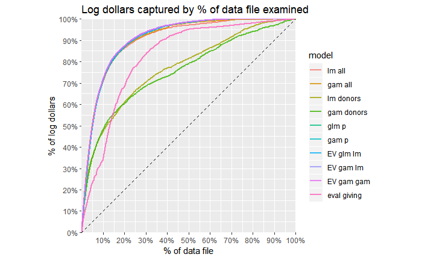

```r
duc_data %>%
  ggplot(aes(x = pct, y = logdollars, color = model)) +
  geom_line(size = 1, alpha = .8) +
  geom_abline(slope = 1, intercept = 0, linetype = 'dashed', col = 'black') +
  scale_x_continuous(breaks = seq(0, 1, by = .1)
                     , labels = seq(0, 1, by = .1) %>% scales::percent()
                     , expand = c(0, 0)) +
  scale_y_continuous(breaks = seq(0, 1, by = .1)
                     , labels = seq(0, 1, by = .1) %>% scales::percent()
                     , expand = c(0, 0)) +
  coord_equal() +
  labs(
    title = 'Log dollars captured by % of data file examined'
    , x = '% of data file'
    , y = '% of log dollars'
  )
```

Unsurprisingly, the “eval giving” heuristic performs poorly, and the donor-only models perform poorly when run on the full dataset after the top donors have been identified (around 5%).

Calculating the area under the curve:

```r
# Function to calculate area under the curve
calc_auc <- function(modelname, metric) {
  data_subset <- duc_data %>% filter(model == modelname)
  sum(1/nrow(data_subset) * {data_subset %>% select_(metric) %>% unlist()}) %>%
    return()
}
```

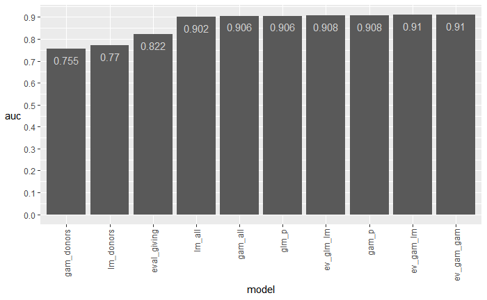

```r
data.frame(
  lm_all = calc_auc('lm all', 'logdollars')
  , gam_all = calc_auc('gam all', 'logdollars')
  , lm_donors = calc_auc('lm donors', 'logdollars')
  , gam_donors = calc_auc('gam donors', 'logdollars')
  , glm_p = calc_auc('gam all', 'logdollars')
  , gam_p = calc_auc('gam p', 'logdollars')
  , ev_glm_lm = calc_auc('EV glm lm', 'logdollars')
  , ev_gam_lm = calc_auc('EV gam lm', 'logdollars')
  , ev_gam_gam = calc_auc('EV gam gam', 'logdollars')
  , eval_giving = calc_auc('eval giving', 'logdollars')
) %>% gather('model', 'auc', lm_all:eval_giving) %>%
  ggplot(aes(x = reorder(model, auc, FUN = mean), y = auc)) +
  geom_bar(stat = 'identity') +
  geom_text(aes(label = round(auc, 3), y = auc - .05), color = 'lightgray') +
  scale_y_continuous(breaks = seq(0, 1.1, by = .1)) +
  labs(x = 'model') +
  theme(axis.text.x = element_text(angle = 90, hjust = 1, vjust = .5), axis.title.y = element_text(angle = 0, vjust = .5))
```

Interestingly, this validates my earlier conclusion that the lm donor model may outperform the gam donor model. The expected value product models (using a gam for the probability piece) do indeed perform slightly better than the others.

Now repeat the exercise with raw (untransformed) dollars.

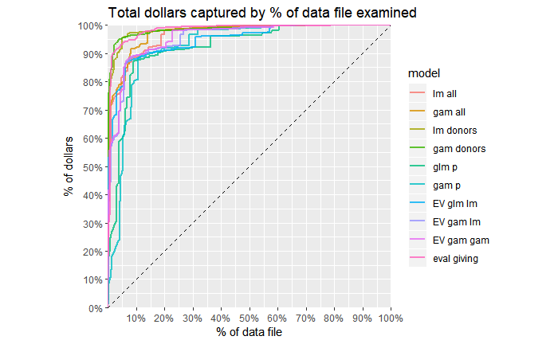

```r
duc_data %>%
  ggplot(aes(x = pct, y = dollars, color = model)) +
  geom_line(size = 1, alpha = .8) +
  geom_abline(slope = 1, intercept = 0, linetype = 'dashed', col = 'black') +
  scale_x_continuous(breaks = seq(0, 1, by = .1)
                     , labels = seq(0, 1, by = .1) %>% scales::percent()
                     , expand = c(0, 0)) +
  scale_y_continuous(breaks = seq(0, 1, by = .1)
                     , labels = seq(0, 1, by = .1) %>% scales::percent()
                     , expand = c(0, 0)) +
  coord_equal() +
  labs(
    title = 'Total dollars captured by % of data file examined'
    , x = '% of data file'
    , y = '% of dollars'
  )
```

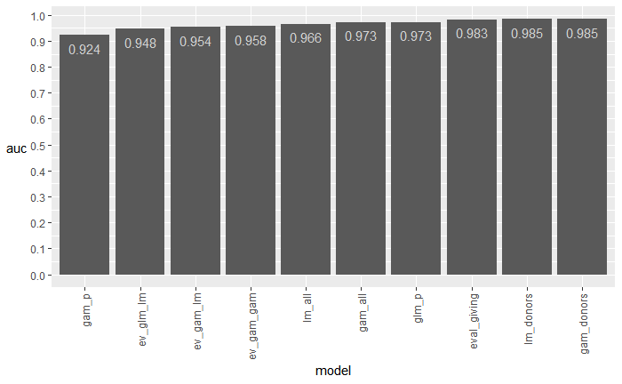

```r
data.frame(
  lm_all = calc_auc('lm all', 'dollars')
  , gam_all = calc_auc('gam all', 'dollars')
  , lm_donors = calc_auc('lm donors', 'dollars')
  , gam_donors = calc_auc('gam donors', 'dollars')
  , glm_p = calc_auc('gam all', 'dollars')
  , gam_p = calc_auc('gam p', 'dollars')
  , ev_glm_lm = calc_auc('EV glm lm', 'dollars')
  , ev_gam_lm = calc_auc('EV gam lm', 'dollars')
  , ev_gam_gam = calc_auc('EV gam gam', 'dollars')
  , eval_giving = calc_auc('eval giving', 'dollars')
) %>% gather('model', 'auc', lm_all:eval_giving) %>%
  ggplot(aes(x = reorder(model, auc, FUN = mean), y = auc)) +
  geom_bar(stat = 'identity') +
  geom_text(aes(label = round(auc, 3), y = auc - .05), color = 'lightgray') +
  scale_y_continuous(breaks = seq(0, 1.1, by = .1)) +
  labs(x = 'model') +
  theme(axis.text.x = element_text(angle = 90, hjust = 1, vjust = .5), axis.title.y = element_text(angle = 0, vjust = .5))
```

Now the heuristic performs very well, but interestingly it is still outperformed by the models fit on donor giving amounts. These results support my earlier conclusions that both expected value and expected giving should be considered when prioritizing prospects.